# R Notebook

Lets just try to get an idea of what communtiy structure does over time.

```r
library(cowplot)
```

```r
allfasta <- read_lines(here("Hatchery_UVexperiment_All", "asv_Hatchery_UVexperiment_All.fa"))
```

```r
fastaDf <- allfasta %>% enframe() %>%
  mutate(ind = rep(c("ASV","seqquence"), length.out = n())) %>%
  group_by(ind) %>%
  mutate(id = row_number()) %>%
  select(-name) %>%
  pivot_wider(names_from = ind, values_from = value) %>%
  select(-id) %>%
  mutate(nASV = parse_number(ASV))
```

```r
hatch %>% group_taxa(Phylum)
```

| Phylum | Sample0 | count | ratio | ASV | Kingdom | Class | Order | Family | Genus | nASV | TagLevel | Tag | Tag_ASV | n | OysterCount | File | Sample | Date | Group | Initials | Tank | Brood# | Tube# | Primer set | Notes | Project | ReadDir | Run | Type | … |
| --- | --- | --- | --- | --- | --- | --- | --- | --- | --- | --- | --- | --- | --- | --- | --- | --- | --- | --- | --- | --- | --- | --- | --- | --- | --- | --- | --- | --- | --- | --- |
| Acidobacteria | H138 | 0 | 0.000000e+00 | ASV_207 | Bacteria | Holophagae | Acanthopleuribacterales | Acanthopleuribacteraceae | Acanthopleuribacter | 207 | Genus | Acanthopleuribacter | Acanthopleuribacter;207 | 69 | 75913 | H138_S17_L001_R1_001.fastq.gz | H138 | 44368 | Hatchery | MH | 5 | 21-38 | 0138 | N719 / S502 | NA | Hatchery | 1 | 1 | Sample | … |
| Acidobacteria | H141 | 0 | 0.000000e+00 | ASV_207 | Bacteria | Holophagae | Acanthopleuribacterales | Acanthopleuribacteraceae | Acanthopleuribacter | 207 | Genus | Acanthopleuribacter | Acanthopleuribacter;207 | 69 | 71119 | H141_S18_L001_R1_001.fastq.gz | H141 | 44371 | Hatchery | HD | 6 | 21-38 | 0141 | N719 / S503 | NA | Hatchery | 1 | 1 | Sample | … |
| Acidobacteria | H144 | 5 | 7.286824e-05 | ASV_207 | Bacteria | Holophagae | Acanthopleuribacterales | Acanthopleuribacteraceae | Acanthopleuribacter | 207 | Genus | Acanthopleuribacter | Acanthopleuribacter;207 | 69 | 68617 | H144_S19_L001_R1_001.fastq.gz | H144 | 44375 | Hatchery | MH | 7 | 21-38 | 0144 | N719 / S505 | 21-38 | Hatchery | 1 | 1 | Sample | … |
| Acidobacteria | H148 | 0 | 0.000000e+00 | ASV_207 | Bacteria | Holophagae | Acanthopleuribacterales | Acanthopleuribacteraceae | Acanthopleuribacter | 207 | Genus | Acanthopleuribacter | Acanthopleuribacter;207 | 69 | 62755 | H148_S20_L001_R1_001.fastq.gz | H148 | 44376 | Hatchery | MH | 8 | 21-43 | 0148 | N719 / S506 | NA | Hatchery | 1 | 1 | Sample | … |
| Acidobacteria | H152 | 0 | 0.000000e+00 | ASV_207 | Bacteria | Holophagae | Acanthopleuribacterales | Acanthopleuribacteraceae | Acanthopleuribacter | 207 | Genus | Acanthopleuribacter | Acanthopleuribacter;207 | 69 | 28021 | H152_S21_L001_R1_001.fastq.gz | H152 | 44379 | Hatchery | LD | 7 | 21-43 | 0152 | N719 / S507 | NA | Hatchery | 1 | 1 | Sample | … |
| Acidobacteria | H158 | 11 | 2.163949e-04 | ASV_207 | Bacteria | Holophagae | Acanthopleuribacterales | Acanthopleuribacteraceae | Acanthopleuribacter | 207 | Genus | Acanthopleuribacter | Acanthopleuribacter;207 | 69 | 50833 | H158_S22_L001_R1_001.fastq.gz | H158 | 44383 | Hatchery | MH | 8 | 21-43 | 0158 | N719 / S508 | NA | Hatchery | 1 | 1 | Sample | … |
| Acidobacteria | H192 | 0 | 0.000000e+00 | ASV_207 | Bacteria | Holophagae | Acanthopleuribacterales | Acanthopleuribacteraceae | Acanthopleuribacter | 207 | Genus | Acanthopleuribacter | Acanthopleuribacter;207 | 69 | 70637 | H192_S25_L001_R1_001.fastq.gz | H192 | 44404 | Hatchery | MH | 7 | 21-56 | 0192 | N720 / S502 | NA | Hatchery | 1 | 1 | Sample | … |
| Acidobacteria | H195 | 3 | 5.941300e-05 | ASV_207 | Bacteria | Holophagae | Acanthopleuribacterales | Acanthopleuribacteraceae | Acanthopleuribacter | 207 | Genus | Acanthopleuribacter | Acanthopleuribacter;207 | 69 | 50494 | H195_S26_L001_R1_001.fastq.gz | H195 | 44406 | Hatchery | MH | 5 | 21-57 | 0195 | N720 / S503 | NA | Hatchery | 1 | 1 | Sample | … |
| Acidobacteria | H196 | 17 | 2.812195e-04 | ASV_207 | Bacteria | Holophagae | Acanthopleuribacterales | Acanthopleuribacteraceae | Acanthopleuribacter | 207 | Genus | Acanthopleuribacter | Acanthopleuribacter;207 | 69 | 60451 | H196_S27_L001_R1_001.fastq.gz | H196 | 44407 | Hatchery | MH | 8 | 21-56 | 0196 | N720 / S505 | NA | Hatchery | 1 | 1 | Sample | … |
| Acidobacteria | H203 | 2 | 3.116381e-05 | ASV_207 | Bacteria | Holophagae | Acanthopleuribacterales | Acanthopleuribacteraceae | Acanthopleuribacter | 207 | Genus | Acanthopleuribacter | Acanthopleuribacter;207 | 69 | 64177 | H203_S28_L001_R1_001.fastq.gz | H203 | 44410 | Hatchery | SA | 2 | 21-57 | 0203 | N720 / S506 | NA | Hatchery | 1 | 1 | Sample | … |

[output cut: 990 more lines]

Domain level patterns

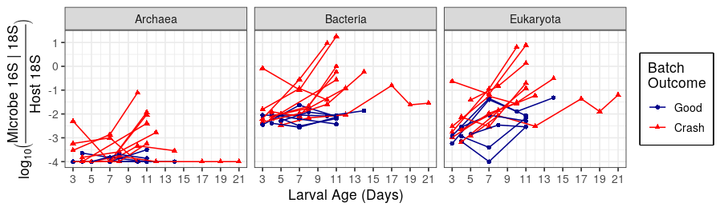

```r
plot_domins <- hatch %>%
  group_taxa(Kingdom) %>%
  #keep_common(fraction = .3, minhits = 5) %>%
  filter(!Info2 %in% c("Charcoal", "Unknown")) %>%
  mutate(Info2 = forcats::fct_relevel(Info2, c("Best", "Ok", "Poor", "NoSurvivors"))) %>%
  mutate(Info1 = forcats::fct_relevel(Info1, c("Good", "Crash"))) %>%
  ggplot(aes(x = as.numeric(DayN), y = log10(ratio + 10^-4), shape = Info1, color = Info1, group = `Brood#`)) +
  geom_point() +
  #scale_color_manual(values = c("black", "darkblue", "orange", "red")) +
  scale_color_manual(values = c(Good = "darkblue", Crash ="red")) +
  geom_path() +
  scale_x_continuous(breaks = c(seq(from = 3, to = 21, by = 2))) + facet_wrap(~Kingdom, nrow = 1) +
  labs(x = "Larval Age (Days)", y = expression(log[10](frac("Microbe 16S | 18S", "Host 18S"))), color = "Batch\nOutcome", shape = "Batch\nOutcome") + theme_bw(base_size = 12) +
    theme(legend.position = "right",
        legend.box.background = element_rect(linewidth = 1))
plot_domins
```

```r
ggsave(here("Figures", "Fig3_DomainLevelPatterns.jpg"), plot = plot_domins, height = 2.5, width = 8.5)
```

Whats with the time-points with two things

```r
hatch %>%
   group_taxa(Kingdom) %>%
   #keep_common(fraction = .3, minhits = 5) %>%
   filter(!Info2 %in% c("Charcoal", "Unknown")) %>%
   mutate(Info2 = forcats::fct_relevel(Info2, c("Best", "Ok", "Poor", "NoSurvivors"))) %>%
   mutate(Info1 = forcats::fct_relevel(Info1, c("Good", "Crash")))  %>%
   filter(Kingdom == "Bacteria") -> bh
bh %>% group_by(`Brood#`, DayN, Info1) %>% summarise(n = n()) %>% arrange(-n) %>% filter(n > 1) %>% arrange(DayN) -> bhs
bhs
```

| Brood# | DayN | Info1 | n |
| --- | --- | --- | --- |

To do: remove tubes 187 and 057 Change DayN of 219 and 213 up front.

```
The first warning was:
ℹ In argument: `Info2 = forcats::fct_relevel(...)`.
ℹ In group 1: `Phylum = "Annelida"`.
Caused by warning:
! 1 unknown level in `f`: Unknown
ℹ Run dplyr::last_dplyr_warnings() to see the 6 remaining warnings.
```

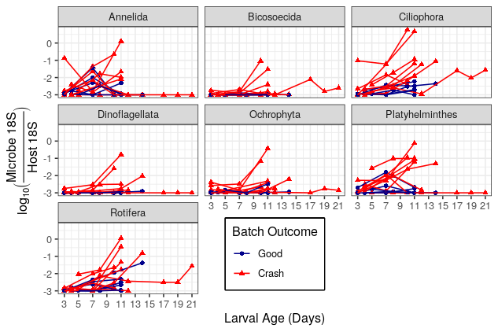

```r
hatch %>%
  group_taxa(Phylum) %>%
  keep_common(fraction = .3, minhits = 5) %>%
  #filter(!Info2 %in% c("Charcoal", "Unknown")) %>%
  mutate(Info2 = recode(Info2, Charcoal = "Unknown")) %>%
  mutate(Info1 = forcats::fct_relevel(Info1, c("Good", "Crash"))) %>%
  filter(Kingdom == "Eukaryota") %>%
  mutate(Info2 = forcats::fct_relevel(Info2, c("Best", "Ok", "Poor", "Unknown", "NoSurvivors"))) %>%
  ggplot(aes(x = as.numeric(DayN), y = log10(ratio + 1/1000), shape = Info1, color = Info1, group = `Brood#`)) + geom_point() +
  #scale_color_manual(values = c("black", "darkblue", "orange", "grey", "red")) +
  scale_color_manual(values = c(Good = "darkblue", Crash ="red")) +
  geom_path() +
  scale_x_continuous(breaks = c(seq(from = 3, to = 21, by = 2))) + facet_wrap(~Phylum) +
  labs(x = "Larval Age (Days)", y = expression(log[10](frac("Microbe 18S", "Host 18S"))), color = "Batch Outcome", shape = "Batch Outcome") +
  theme_bw() +
  theme(legend.position = c(0.5, 0.15),
        legend.box.background = element_rect(linewidth = 1))
```

Now we are looking at all of the common species of eukaryotes (old color scheme only)

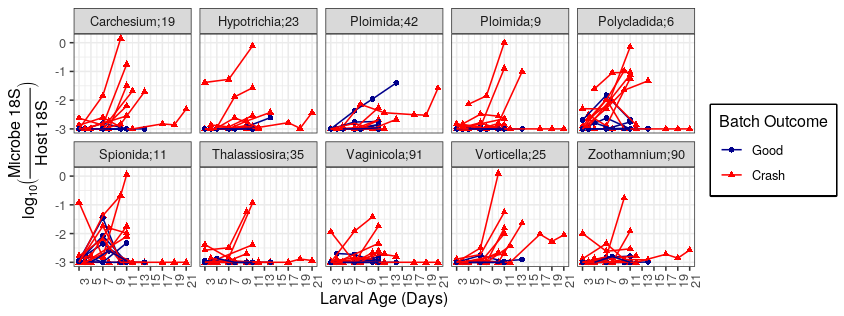

```r
hatch %>%
  #group_taxa(Tag_ASV) %>%
  keep_common(fraction = .3, minhits = 5) %>%
  #filter(!Info2 %in% c("Charcoal", "Unknown")) %>%
  mutate(Info2 = recode(Info2, Charcoal = "Unknown")) %>%
  mutate(Info1 = forcats::fct_relevel(Info1, c("Good", "Crash"))) %>%
  filter(Kingdom == "Eukaryota") %>%
  mutate(Info2 = forcats::fct_relevel(Info2, c("Best", "Ok", "Poor", "Unknown", "NoSurvivors"))) -> EukASV
EukASV %>%
  ggplot(aes(x = as.numeric(DayN), y = log10(ratio + 1/1000), shape = Info1, color = Info1, group = `Brood#`)) + geom_point() +
  scale_color_manual(values = c("darkblue", "red")) +
  geom_path() +
  scale_x_continuous(breaks = c(seq(from = 3, to = 21, by = 2))) + facet_wrap(~Tag_ASV, nrow = 2) +
  labs(x = "Larval Age (Days)", y = expression(log[10](frac("Microbe 18S", "Host 18S"))), color = "Batch Outcome", shape = "Batch Outcome") +
  theme_bw() +
  theme(legend.position = "right",
        legend.box.background = element_rect(linewidth = 1),
        axis.text.x = element_text(angle = 90))
```

```r
EukASV$Tag %>% unique()
```

```
[1] "Polycladida"   "Ploimida"      "Spionida"      "Carchesium"    "Hypotrichia"   "Vorticella"    "Thalassiosira"
[8] "Zoothamnium"   "Vaginicola"
```

```r
Search_these_Euks <- EukASV$nASV %>% unique()

tax %>%
  filter(nASV %in% (Search_these_Euks)) %>%
  select(nASV, TagLevel, Tag)
```

| nASV | TagLevel | Tag |
| --- | --- | --- |
| 6 | Order | Polycladida |
| 9 | Order | Ploimida |
| 11 | Order | Spionida |
| 19 | Genus | Carchesium |
| 23 | Family | Hypotrichia |
| 25 | Genus | Vorticella |
| 35 | Genus | Thalassiosira |
| 42 | Order | Ploimida |
| 90 | Genus | Zoothamnium |
| 91 | Genus | Vaginicola |

```r
eucSeqDf <- fastaDf %>%
  filter(nASV %in% (Search_these_Euks))

euc_fasta <- c(rbind(eucSeqDf$ASV, eucSeqDf$seqquence))
write(euc_fasta, here("IntermediateData","CommonEukASVs.fa"))
```

There seem to be more than one measurment per day for the “poor”? Is that UV treatment? Again, what are the charcoal and unknown.

## Bacteria

Abundance of common bacterial phyla

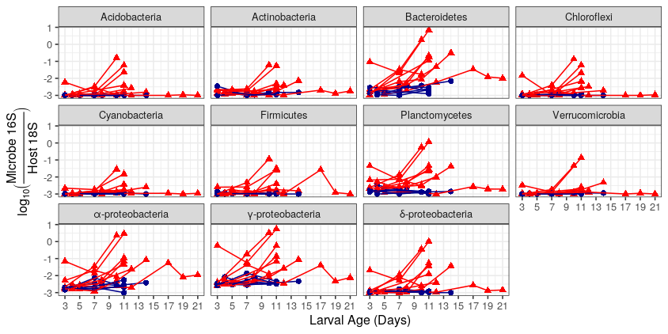

```r
plot_BacterialPhyla <- hatch %>%
  group_taxa(Phylum) %>%
  keep_common(fraction = .3, minhits = 5) %>%
  #filter(!Info2 %in% c("Charcoal", "Unknown")) %>%
  mutate(Info2 = recode(Info2, Charcoal = "Unknown")) %>%
  mutate(Info2 = recode(Info2, Unknown = "Poor")) %>%

  filter(Kingdom == "Bacteria") %>%
  mutate(Info2 = forcats::fct_relevel(Info2, c("Best", "Ok", "Poor", "NoSurvivors"))) %>%
  mutate(Info1 = forcats::fct_relevel(Info1, c("Good", "Crash"))) %>%
  ggplot(aes(x = as.numeric(DayN), y = log10(ratio + 1/1000), shape = Info1, color = Info1, group = `Brood#`)) +
  geom_point(size = 2) + scale_color_manual(values = c("darkblue", "red")) +
  geom_path() +
  scale_x_continuous(breaks = c(seq(from = 3, to = 21, by = 2))) +
  facet_wrap(~Phylum) +
  labs(x = "Larval Age (Days)",y = expression(log[10](frac("Microbe 16S", "Host 18S"))), color = "Batch Outcome", shape = "Batch Outcome") +
  theme_bw() +
  theme(legend.position = "none")
plot_BacterialPhyla
```

Common Bacteriodetes ASVs

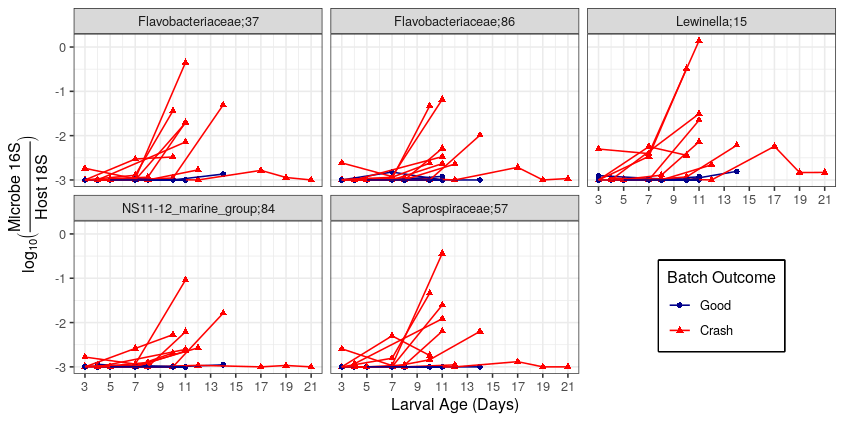

```r
hatch %>%
  #group_taxa(Tag_ASV) %>%
  keep_common(fraction = .3, minhits = 5) %>%
  #filter(!Info2 %in% c("Charcoal", "Unknown")) %>%
  mutate(Info2 = recode(Info2, Charcoal = "Unknown")) %>%
  filter(Phylum == "Bacteroidetes") %>%
  filter(Family != "Mitochondria") %>%
  mutate(Info2 = forcats::fct_relevel(Info2, c("Best", "Ok", "Poor", "Unknown", "NoSurvivors"))) %>%
  mutate(Info1 = forcats::fct_relevel(Info1, c("Good", "Crash"))) -> CommonBacteroidetes
CommonBacteroidetes %>%
  ggplot(aes(x = as.numeric(DayN), y = log10(ratio + 1/1000), shape = Info1, color = Info1, group = `Brood#`)) + geom_point() + scale_color_manual(name = "Batch Outcome", values = c("darkblue", "red")) +
  geom_path() +
  scale_x_continuous(breaks = c(seq(from = 3, to = 21, by = 2))) + facet_wrap(~Tag_ASV) +
  labs(x = "Larval Age (Days)", y = expression(log[10](frac("Microbe 16S", "Host 18S"))), shape = "Batch Outcome") + theme_bw() +
  theme(legend.position = c(0.85, 0.2),
        legend.box.background = element_rect(linewidth = 1))
```

```r
Search_these_Bdd <- CommonBacteroidetes$nASV %>% unique()

tax %>%
  filter(nASV %in% (Search_these_Bdd)) %>%
  select(nASV, TagLevel, Tag)
```

| nASV | TagLevel | Tag |
| --- | --- | --- |
| 15 | Genus | Lewinella |
| 37 | Family | Flavobacteriaceae |
| 57 | Family | Saprospiraceae |
| 84 | Family | NS11-12_marine_group |
| 86 | Family | Flavobacteriaceae |

```r
bddSeqDf <- fastaDf %>%
  filter(nASV %in% (Search_these_Bdd))

bdd_fasta <- c(rbind(bddSeqDf$ASV, bddSeqDf$seqquence))
write(bdd_fasta, here("IntermediateData","CommonBacteroidetesASVs.fa"))
```

Common Gammaproteobacterial, As Vs

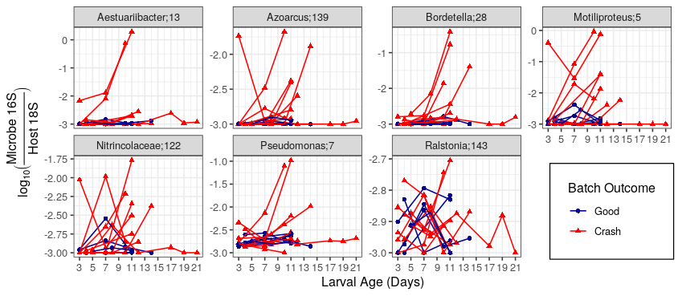

```r
 hatch %>%
  #group_taxa(Tag_ASV) %>%
  keep_common(fraction = .3, minhits = 5) %>%
  #filter(!Info2 %in% c("Charcoal", "Unknown")) %>%
  mutate(Info2 = recode(Info2, Charcoal = "Unknown")) %>%
  mutate(Info1 = forcats::fct_relevel(Info1, c("Good", "Crash"))) %>%
  filter(Class == "Gammaproteobacteria") %>%
  filter(Family != "Mitochondria") -> Gpr

plot_GammaProteobacteria <- Gpr %>%
  #mutate(Info2 = forcats::fct_relevel(Info2, c("Best", "Ok", "Poor", "Unknown", "NoSurvivors"))) %>%
  ggplot(aes(x = as.numeric(DayN), y = log10(ratio + 1/1000), shape = Info1, color = Info1, group = `Brood#`)) + geom_point() + scale_color_manual(values = c("darkblue", "red")) + geom_path() +
  scale_x_continuous(breaks = c(seq(from = 3, to = 21, by = 2))) + facet_wrap(~ Tag_ASV, scales = "free_y", nrow = 2) +
  labs(x = "Larval Age (Days)", y = expression(log[10](frac("Microbe 16S", "Host 18S"))), color = "Batch Outcome", shape = "Batch Outcome") + theme_bw() +
  theme(legend.position = c(0.9, 0.2),
        legend.box.background = element_rect(linewidth = 0.4),
        legend.box.margin = margin(10, 10,10, 10))
plot_GammaProteobacteria
```

Figure 4 is Bacterial Phyla Plus Gammaproteobacteria

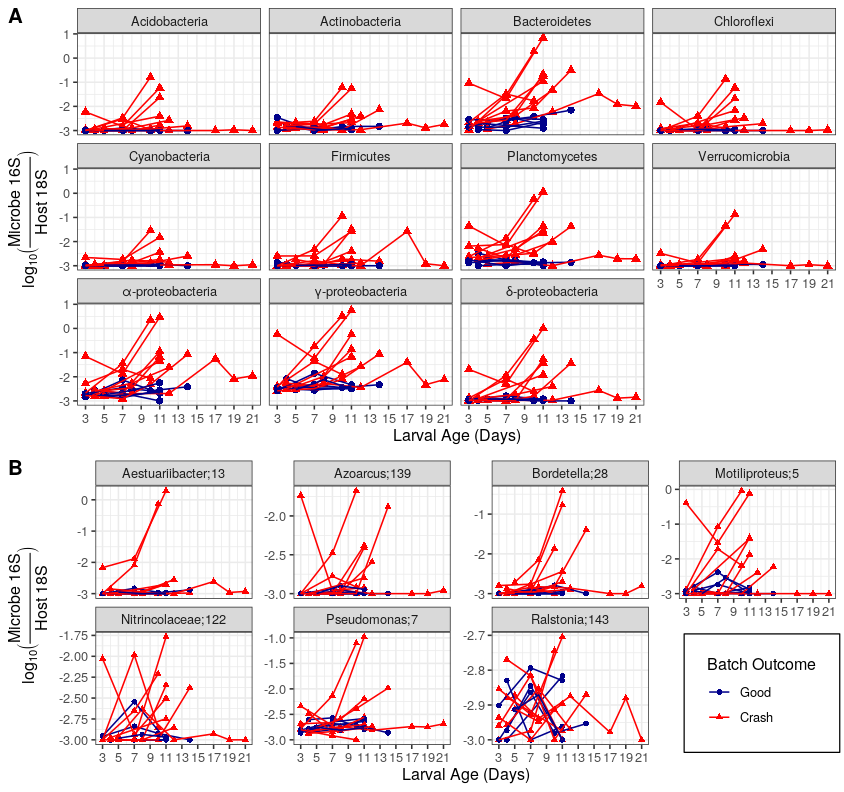

```r
plot_PhylaGamma <- cowplot::plot_grid(
  plot_BacterialPhyla, plot_GammaProteobacteria, nrow = 2, labels = c("A", "B"), rel_heights = c(4, 3)
)
plot_PhylaGamma
```

```r
ggsave(here("Figures", "Fig4_PhylaGamma.jpg"), plot_PhylaGamma, height = 7.5, width = 9)
```

Return names for searching

```r
Gpr$Tag %>% unique()
```

```
[1] "Motiliproteus"   "Pseudomonas"     "Aestuariibacter" "Bordetella"      "Nitrincolaceae"  "Azoarcus"
[7] "Ralstonia"
```

```r
Search_these_gammas <- Gpr$nASV %>% unique()

tax %>%
  filter(nASV %in% (Search_these_gammas)) %>%
  select(nASV, TagLevel, Tag)
```

| nASV | TagLevel | Tag |
| --- | --- | --- |
| 5 | Genus | Motiliproteus |
| 7 | Genus | Pseudomonas |
| 13 | Genus | Aestuariibacter |
| 28 | Genus | Bordetella |
| 122 | Family | Nitrincolaceae |
| 139 | Genus | Azoarcus |
| 143 | Genus | Ralstonia |

```r
gammaSeqDf <- fastaDf %>%
  filter(nASV %in% (Search_these_gammas))

gamma_fasta <- c(rbind(gammaSeqDf$ASV, gammaSeqDf$seqquence))
write(gamma_fasta, here("IntermediateData","CommonGammaASVs.fa"))
```

The common cyanobacterial ASVs are all chloroplasts. I should maybe remove those.

Are there vibrio?

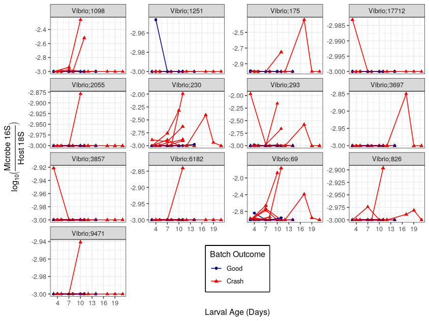

```r
hvib <- hatch %>%
  filter(Genus == "Vibrio")

Present_vibreos <- hvib %>% group_by(Tag_ASV) %>% summarise(totrat = sum(ratio)) %>% filter(totrat > 0) %>% pull(Tag_ASV)
hvib <- hvib %>% filter(Tag_ASV %in% Present_vibreos)

hvib %>%
  mutate(Info2 = forcats::fct_relevel(Info2, c("Best", "Ok", "Poor", "Unknown", "NoSurvivors"))) %>%
  mutate(Info1 = forcats::fct_relevel(Info1, c("Good", "Crash"))) %>%

  ggplot(aes(x = as.numeric(DayN), y = log10(ratio + 1/1000), shape = Info1, color = Info1, group = `Brood#`)) + geom_point() + scale_color_manual(values = c("darkblue", "red")) + geom_path() +
  scale_x_continuous(breaks = seq(from = 1, to = 20, by = 3)) + facet_wrap(~Tag_ASV, scales = "free_y") +
   labs(x = "Larval Age (Days)", y = expression(log[10](frac("Microbe 16S", "Host 18S"))), shape = "Batch Outcome", color = "Batch Outcome") + theme_bw() +
  theme(legend.position = c(0.5, 0.1),
        legend.box.background = element_rect(linewidth = 1))
```

I kind of want “examples”. Maybe two eukaryotes, three bacteria and a legend.

Pull vibreo sequences

```r
Present_vibreos %>% parse_number()
```

```
 [1]  1098  1251   175 17712  2055   230   293  3697  3857  6182    69   826  9471
```

```r
vibSeqDf <- fastaDf %>%
  filter(nASV %in% (Present_vibreos %>% parse_number()))
```

```r
vib_fasta <- c(rbind(vibSeqDf$ASV, vibSeqDf$seqquence))
write(vib_fasta, here("IntermediateData","vibrios.fa"))
```

## Blasting the vibrios

I blasted the vibrio fasta file on ncbi and then parsed the species names out of the text file output.

```r
source(here("RScripts", "Parse_NCBI_Vibrio.R"))
```

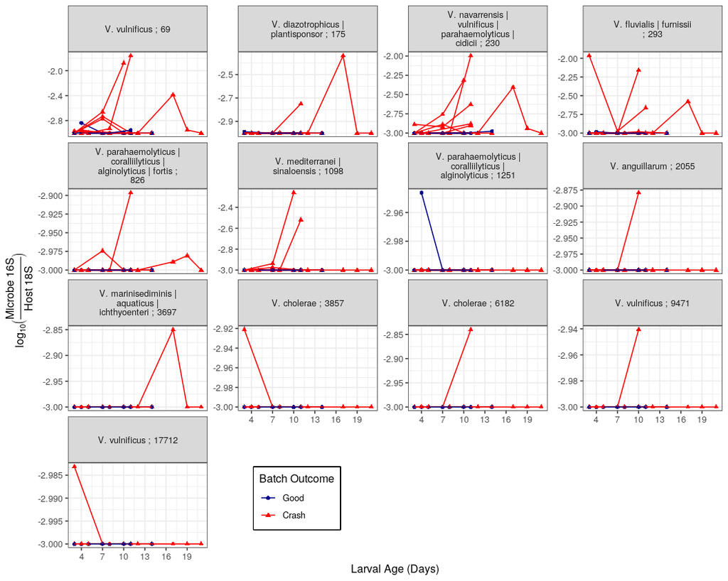

```r
hvibS <- hvib %>%
  left_join(vibrio_species_tags, by = "ASV")

vplt <- hvibS %>%
  mutate(Info1 = forcats::fct_relevel(Info1, c("Good", "Crash"))) %>%
  ggplot(aes(x = as.numeric(DayN), y = log10(ratio + 1/1000), shape = Info1, color = Info1, group = `Brood#`)) + geom_point() + scale_color_manual(values = c("darkblue", "red")) + geom_path() +
  scale_x_continuous(breaks = seq(from = 1, to = 20, by = 3)) + facet_wrap(~Tag_species, scales = "free_y", labeller = label_wrap_gen()) +
   labs(x = "Larval Age (Days)", y = expression(log[10](frac("Microbe 16S", "Host 18S"))), shape = "Batch Outcome", color = "Batch Outcome") + theme_bw() +
  theme(legend.position = c(0.35, 0.1),
        legend.box.background = element_rect(linewidth = 1))
vplt
```

# Combined figure for proposal

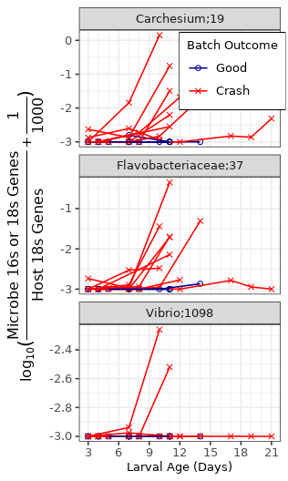

```r
sg_follow_plot <- hatch %>%
  mutate(Info1 = forcats::fct_relevel(Info1, c("Good", "Crash"))) %>%
  #keep_common(fraction = .3, minhits = 5) %>%
  filter(nASV  %in% c(19, 37, 1098)) %>%
  group_by(Tag_ASV, DayN, Info1, `Brood#`) %>%
  summarise(ratio = mean(ratio), .groups = "keep") %>%
  arrange(as.numeric(DayN)) %>%
  ggplot(aes(x = as.numeric(DayN), y = log10(ratio + 1/1000), shape = Info1, color = Info1, group = `Brood#`)) + geom_point() +      scale_color_manual(values = c( "darkblue", "red")) +
  scale_shape_manual(values = c(1, 4)) +
  geom_path() +
  scale_x_continuous(breaks = seq(from = 0, to = 27, by = 3), minor_breaks = 1:27) + facet_wrap(~Tag_ASV, ncol = 1, scales = "free_y") +
  labs(x = "Larval Age (Days)", color = "Batch Outcome", shape = "Batch Outcome", y = expression(log[10](frac('Microbe 16s or 18s Genes','Host 18s Genes') + frac(1,1000)))) + theme_bw(base_family = 12) +
  theme(legend.position = c(0.76, 0.9), legend.title = element_text(size = 9), legend.box.background = element_rect(colour = "black"), axis.title.x = element_text(size = 9))
ggsave(here("Figures", "SG_Follow_Exemplars.png"), width = 3, height = 5, plot = sg_follow_plot)
sg_follow_plot
```

# Pirellulaceae;205

Is statistically associated with crashes at time point 3-5.

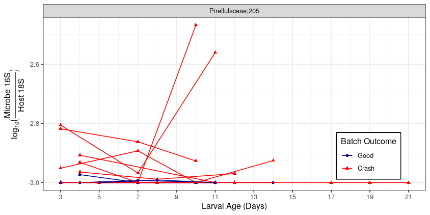

```r
hatch %>%
  filter(Tag_ASV == "Pirellulaceae;205") %>%
  mutate(Info1 = forcats::fct_relevel(Info1, c("Good", "Crash"))) %>%
  ggplot(aes(x = as.numeric(DayN), y = log10(ratio + 1/1000), shape = Info1, color = Info1, group = `Brood#`)) + geom_point() + scale_color_manual(name = "Batch Outcome", values = c("darkblue", "red")) +
  geom_path() +
  scale_x_continuous(breaks = c(seq(from = 3, to = 21, by = 2))) + facet_wrap(~Tag_ASV) +
  labs(x = "Larval Age (Days)", y = expression(log[10](frac("Microbe 16S", "Host 18S"))), shape = "Batch Outcome") + theme_bw() +
  theme(legend.position = c(0.85, 0.2),
        legend.box.background = element_rect(linewidth = 1))
```

```r
print(fastaDf[205,2][[1]])
```

```
[1] "TACGGAGGGTGCAAGCGTTATCCGGAATCACTGGGTTTAAAGGGTGCGTAGGCGGCGCAA…"
```

Dinophyceae Class

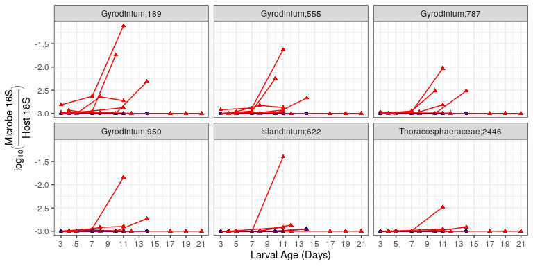

```r
hatch %>%
  #group_taxa(Tag_ASV) %>%
  keep_common(fraction = .05, minhits = 5) %>%
  #filter(!Info2 %in% c("Charcoal", "Unknown")) %>%
  mutate(Info2 = recode(Info2, Charcoal = "Unknown")) %>%
  filter(Class == "Dinophyceae") %>%
  #mutate(Info2 = forcats::fct_relevel(Info2, c("Best", "Ok", "Poor", "Unknown", "NoSurvivors"))) %>%
  mutate(Info1 = forcats::fct_relevel(Info1, c("Good", "Crash"))) -> DinophyceaeData

plot_Dinophyceae <- DinophyceaeData %>%
  ggplot(aes(x = as.numeric(DayN), y = log10(ratio + 1/1000), shape = Info1, color = Info1, group = `Brood#`)) + geom_point() + scale_color_manual(name = "Batch Outcome", values = c("darkblue", "red")) +
  geom_path() +
  scale_x_continuous(breaks = c(seq(from = 3, to = 21, by = 2))) + facet_wrap(~Tag_ASV) +
  labs(x = "Larval Age (Days)", y = expression(log[10](frac("Microbe 16S", "Host 18S"))), shape = "Batch Outcome") + theme_bw() +
  theme(legend.position = "none")

plot_Dinophyceae
```

```r
print(fastaDf[189,2][[1]])
```

```
[1] "TACGGAGGATCCAAGCGTTATCCGGAATCATTGGGTTTAAAGGGTCCGTAGGCGGCCTTA…"
```

Make fasta file

```r
Search_these_Dinophyceae <- DinophyceaeData$nASV %>% unique()


dinSeqDf <- fastaDf %>%
  filter(nASV %in% (Search_these_Dinophyceae))

din_fasta <- c(rbind(dinSeqDf$ASV, dinSeqDf$seqquence))
write(din_fasta, here("IntermediateData","Dynophyceae.fa"))
```